# Intro to gaussian processes

Glenn Palmer

2023-02-18

## Introduction

In my previous posts about splines, the main goal was to model a nonlinear relationship between some variables x and y. First, we saw **B-splines**, a type of *basis function* that can easily be used in a linear regression model for one or more covariates. But then, we had some doubts about choosing too few or too many of these functions, or choosing suboptimal placement of the “knots” where the functions meet each other. To address this, we introduced **P-splines** (where the P stands for “penalized”). Through *regularization* (or equivalently, through placing a clever Bayesian prior) on the coefficients of the spline functions, we pushed the resulting curve estimate to be smooth and numerically stable, even for an arbitrarily large number of basis functions.

In many contexts, the splines described in those posts can be incredibly useful, and if you’re just starting to think about modeling nonlinear relationships, I might start by reading those ahead of this one. But, if you’re looking to expand your toolbox further, there’s another approach that’s some combination of more elegant, more abstract, more Bayesian, and more mathy that uses something called a **Gaussian process**. At the risk of scaring some readers off, a Gaussian process is an example of something called a **random function**. To find out what that means, read on.

## Background – random variables and random vectors

To get an intuition for what a random function is, I’m going to start slow and build up to it. I’m hoping you’ve heard of a **random variable** – for example, you might have a random variable $X$ that’s normally distributed with mean 0 and variance 1. We’d write that as:

$$X \sim N(0,1)$$

What this means is that if we take a “draw” from the distribution of $X$, the probability that it takes a value in any particular range can be calculated from the normal distribution function. In this case, if we generate a bunch of independent draws from the N(0,1) distribution, i.e.,
$$X_1, ...,X_n \overset{iid}{\sim} N(0,1),$$
and visualize them as a histogram, they start to resemble the “bell curve” you see everywhere in intro probability/stats.

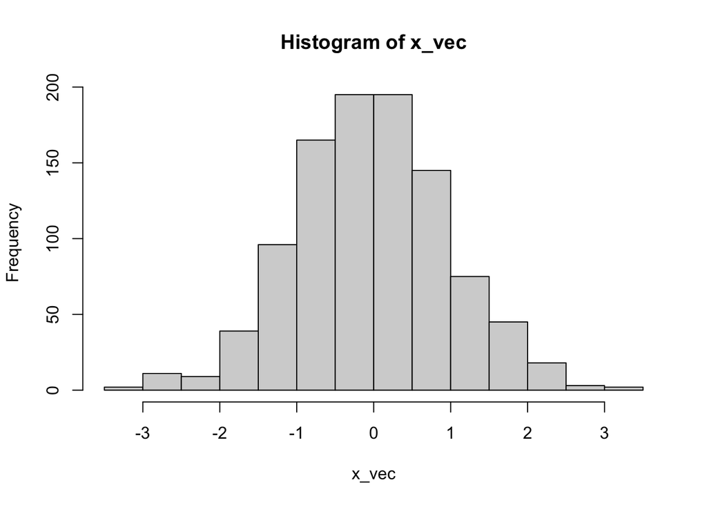

```r
x_vec <- rnorm(n=1000, mean=0, sd=1)
hist(x_vec)
```

Once you learned about random variables, you may have learned about an extension of these called **random vectors**. Conceptually, they aren’t a huge leap from random variables – just instead of having a distribution for what value a single variable could take on, you have a distribution for what values a pair of variables, or a set of three, or four, or ten, or a thousand could take on. Extending the above, a common example here is the multivariate normal distribution. In two dimensions, this normal distribution just has a mean for each of the two variables, a variance for each of the two variables, and a correlation between the two variables.

E.g., if we had

$$\begin{pmatrix}
X_1 \\
X_2
\end{pmatrix} \sim
N\left(\begin{pmatrix}
2 \\
3
\end{pmatrix},
\begin{pmatrix}
1 & 0.8 \\
0.8 & 1
\end{pmatrix}
\right)$$
then if we draw a bunch of these two-dimensional vectors, the first element will have mean 2, the second will have mean 3, each component separately will have a variance of 1, and they’ll have a correlation of 0.8. To visualize what a bunch of draws from this distribution would look like, we can simulate from it and plot the results in two dimensions.

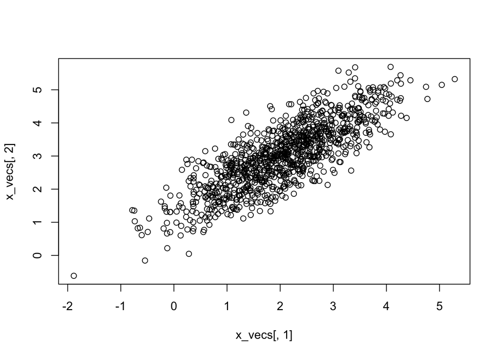

```r
library(mvtnorm)
x_vecs <- rmvnorm(n=1000, mean=c(2,3), sigma=matrix(data=c(1,0.8,0.8,1), nrow=2))
plot(x=x_vecs[,1], y=x_vecs[,2])
```

Looking at the graph above, we see the points roughly centered around the point (2,3) as expected, and they have a strong positive correlation – that is, when $X_1$ is larger than average, the corresponding $X_2$ tends to be larger than average as well.

Side note – if we plot the distributions of our $X_1$ and $X_2$ draws separately, we again see the bell shape from earlier, but just with different means.

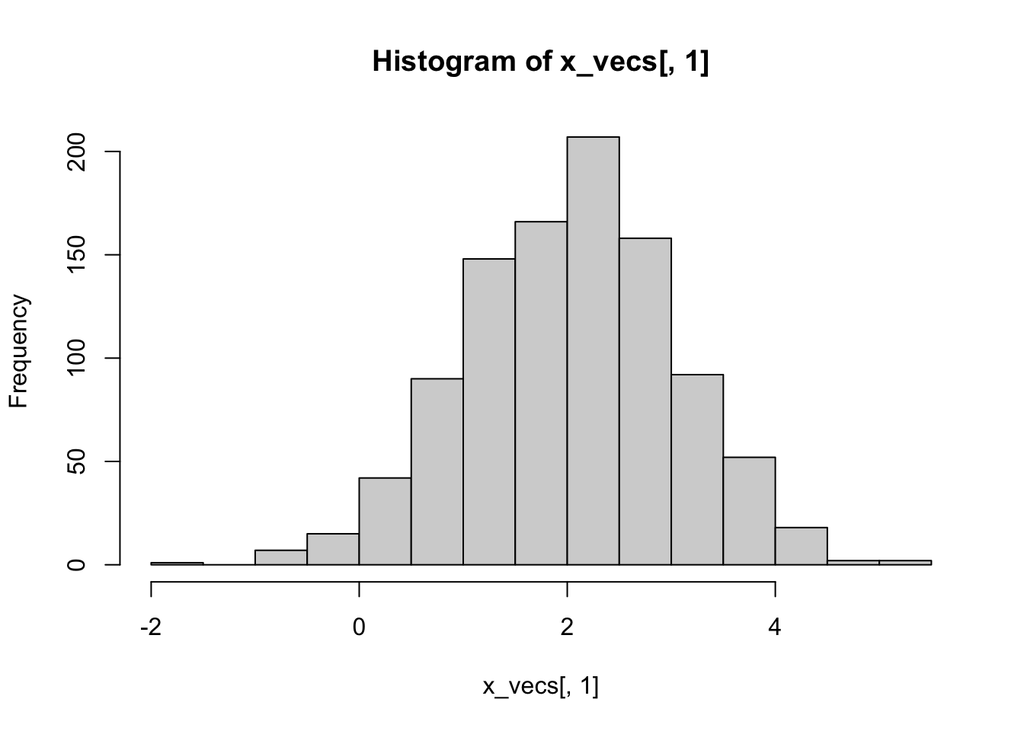

```r
hist(x_vecs[,1])
```

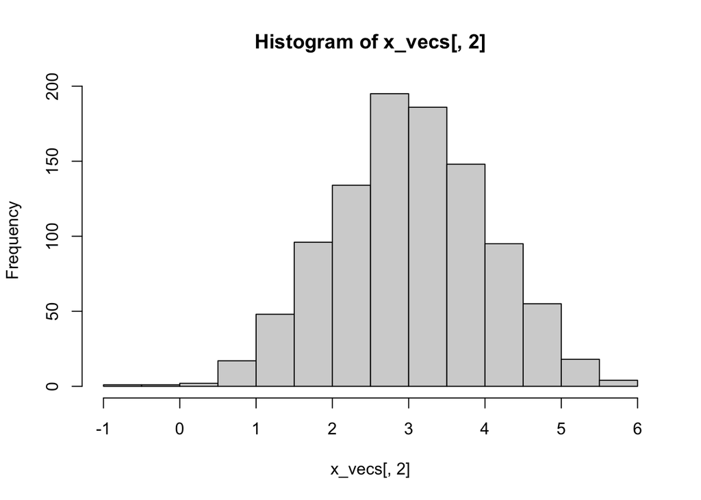

```r
hist(x_vecs[,2])
```

## Ok… but what’s a random function??

In simplest terms, a random function is basically just a combination of the ideas of random variables and random vectors above with the definition of a function you learned in middle school.

To start, let’s think about the one-dimensional case. If I have a variable $y$ that’s some (non-random) function $f$ of a variable $x$, where $x$ can take on any real number, then if I give you any value $x$, you can plug into $f(x)$ to get the value of $y$. (Simple example – if we define $y = f(x) = 3x$, then if I give you $x=2$, you know that $y=6$). In a *random* function, the thing that’s random here is the actual *function* $f$ – i.e., the formula or rule mapping $x$ to $y$ is the thing that has a distribution we can take “draws” from.

I think at first, this seems super weird and abstract – like what does it mean for a function to have a probability distribution?? If we try to think about a random function as a random vector of $y$-values corresponding to each possible $x$-value, we would need to draw a value of $f(x)$ for every real value of $x$… but this means our random vector would need to be uncountably infinitely long!?!?

To deal with these philosophical quandries, in practice we have to make some simplifying assumptions that constrain what type of function $f$ can be. One veeeery simple example of how you might think to define a random function $f$ is just to say that $f$ is a linear function that goes through the origin, and the slope of $f$ is normally distributed with mean 0 and variance 1. (Weirdly, this actually turns out to be an example of a Gaussian process – more on this later.) For this example, we could write

$$f(x) = Mx \\
M \sim N(0,1)$$

With this definition, we don’t have to work very hard to take a draw of $f$ – we just have to draw M from the N(0,1) distribution and then $f$ is completely defined for all $x$! Let’s do this and visualize some draws from our linear random function below:

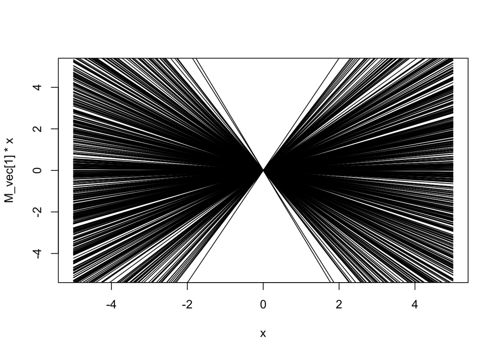

```r
# draw slopes
M_vec <- rnorm(n=500, mean=0, sd=1)

# plot first random line
x <- seq(from=-5, to=5, by=0.1)
plot(x=x, y=M_vec[1]*x, type="l", xlim=c(-5,5), ylim=c(-5,5))

# plot random lines 2 through 500
for (i in 2:length(M_vec)) {
  lines(x=x, y=M_vec[i]*x)
}
```

Beyond looking like a bowtie (or when they go light-speed or whatever in Star Wars??), the above should start to make you think about what we’re doing. We get this distribution over linear relationships between x and y that we can visualize really nicely. Here, we’re just letting the slope have mean 0 and variance 1 and fixing the intercept to 0. But you could imagine “learning” distributions of the slope and intercept from observed data and hence, learning a “posterior distribution” over these linear functions. That’s essentially what Bayesian linear regression is, which is really just the simplest version of Gaussian process regression.

## Finally… what the heck is a Gaussian process??

Ok if you’re still with me, we’re finally there. Using the terms we built up above:

- Definition: A **Gaussian process** is a random function $f(x)$ such that if we take any finite set of input values $x_1,..,x_n$, then the vector $(f(x_1),...,f(x_n))$ is a random vector with a multivariate normal distribution.

If you’re like me, even if you know all the individual words in that definition, it still might leave your head spinning a little. So, let’s try to unpack it. We have this function $f$ that’s random. But for a given draw of $f$, we learned in middle school that it can take any real value $x$ and spit out a real value for $y$. What this definition is saying is that if I secretly think up some specific values of $x$ beforehand (to be more concrete let’s say we define $x_1=-1$, $x_2=4$, $x_3=5.6$, $x_4=20$) then we take a bunch of random draws of $f$ without thinking at all about the $x$’s we chose, then if $f$ is a Gaussian process, it magically works out that the distribution of our draws of the values of $(f(-1),f(4),f(5.6),f(20))$ is a four-dimensional normal distribution.

I’d ponder this a little until it starts to make like 70% sense, then read on.

## Ok now we have a definition. But how can I define an actual Gaussian process distribution and draw from it??

To think about how we could define such a distribution over functions, let’s just think about what we need to have access to in order to accomplish the above. For an arbitrary number $n$ of arbitrary $x$-values, the definition above says that I need to be able to calculate the mean of each $f(x)$ as well as the $n \times n$-dimensional covariance matrix – then using these I can define the multivariate normal distribution for the $f(x)$’s. To do this for arbitrary (and arbitrarily many) values of $x$, what I need to define here is a *mean function* that takes input values of $x$ and spits out the expected value of $f(x)$, and a *covariance function* that takes as input pairs of values $(x_1,x_2)$ and spits out the covariance between $f(x_1)$ and $f(x_2)$. If I have these two functions, then if you give me a list of any values $x_1,...,x_n$, I can just do a bunch of tedious plugging into $\mu$ and $K$ and get the mean vector and covariance matrix for the multivariate normal distribution of $f(x_1),...,f(x_n)$.

The notation I’ve seen most places seems to call the mean function $\mu$ and the covariance function $K$. (Note: the $K$ here refers to the fact that the covariance functions here are often referred to as “kernels”.) Using this notation, in the same way that we can define a normal distribution by its mean and variance, we can define a Gaussian process distribution by defining $\mu$ and $K$. For a given choice of $\mu$ and $K$, we can define a distribution

$$f \sim GP(\mu, K)$$

so that for any $x_1$ and $x_2$ in the domain of $f$:

$$E[f(x_1)] = \mu(x_1)\\
E[f(x_2)] = \mu(x_2)\\
Cov(f(x_1), f(x_2)) = K(x_1, x_2).$$

To be even more specific, for any $x_1$ and $x_2$ in the domain of $f$, we have that

$$\begin{pmatrix}
f(x_1) \\
f(x_2)
\end{pmatrix} \sim
N\left(\begin{pmatrix}
\mu(x_1) \\
\mu(x_2)
\end{pmatrix},
\begin{pmatrix}
K(x_1,x_1) & K(x_1,x_2) \\
K(x_2,x_1) & K(x_2,x_2)
\end{pmatrix}
\right)$$
and we could define larger multivariate normal distributions for collections of $f(x_1),...,f(x_n)$ as needed, all just using $\mu$ and $K$.

At the risk of demoralizing you since your head may be spinning from reading about this for the first time… that’s it! That’s all a Gaussian process is – it’s just a random function defined by its mean and covariance functions. If this is a little less intuitive than the random lines example above… fair enough. You’ll note that in general by defining the mean and covariance functions, we’re defining distributions over arbitrary collections of points, but we don’t just get to draw a slope or some parameter and then have a nice closed-form expression for our function $f$. The downside of this is a bit of abstraction. The upside is that instead of being constrained to being linear or some other simple type of function, $f$ can be super flexible, taking on forms we’d never be able to express with a simple equation.

## Example: GP with mean zero and RBF kernel

If we want to use a Gaussian process in practice, defining the mean function $\mu$ isn’t a huge deal. When using a GP prior distribution for Bayesian inference, common practice is just to define

$$\mu(x) = 0 \,\,\,\,\,\, \text{for all } \,x.$$

The critical part is how to choose the covariance function (or “kernel”) $K$. There are a bunch of common choices, but maybe the most popular is the radial basis function (or RBF) kernel, defined by:

$$K(x_1,x_2) = \tau^2 \exp(-\frac{1}{2 l^2} |x_1 - x_2|^2)$$

where $\tau$ and $l$ are parameters that should be learned from observed data. We’ll worry about actually learning these parameters through Gaussian process regression in a future post. But for now, let’s just see what some draws from a GP look like when it has mean 0 and an RBF kernel. To visualize a draw from the function, I can just choose a finite set of values $x_1,...x_n$ that are super finely-spaced over an interval and draw them from an $n$-dimensional multivariate normal distribution with mean 0 and covariance defined by plugging into the RBF kernel function defined above.

```r
# set a grid of points x in [0,10]
x <- seq(from = 0, to = 10, by = 0.1)

# set hyperparameter values
l <- 2
tau <- 1

# set the mean vector to zero
mu <- rep(0, length(x))

# function to give RBF covariance between two x's
K <- function(x1, x2, l, tau) {
  return(tau^2 * exp(-(x1 - x2)^2 / (2 * l^2)))
}

# form the covariance matrix for x
K_mat <- matrix(nrow = length(x), ncol = length(x))
for (i in 1:length(x)) {
  for (j in 1:length(x)) {
    K_mat[i,j] <- K(x[i], x[j], l, tau)
  }
}
```

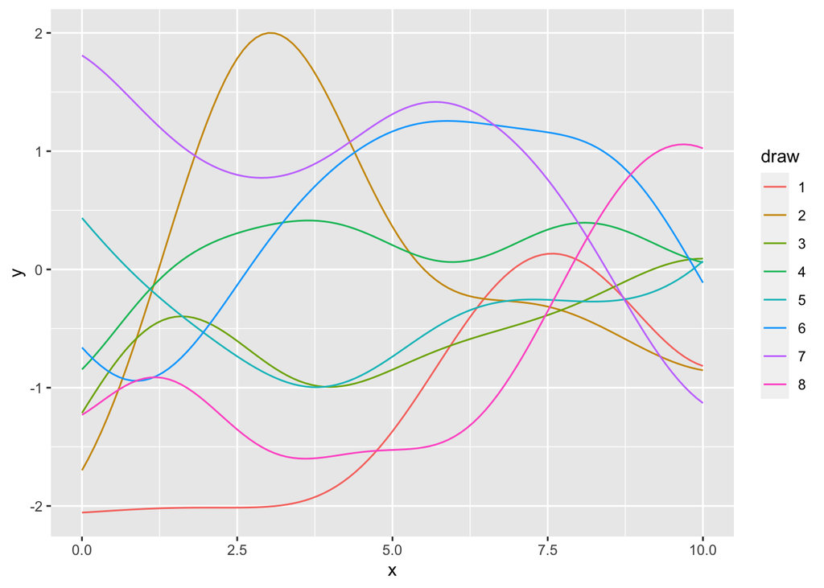

```r
library(tidyverse)
# draw from prior above
prior_draws <- rmvnorm(n = 8, mean = mu, sigma = K_mat)

# create dataframe for visualizing draws
prior_df <- cbind(data.frame(x), t(prior_draws)) |>
  pivot_longer(
    cols = !x,
    names_to = "draw",
    values_to = "y"
  )

# plot draws
ggplot(data = prior_df, aes(x = x, y = y, color = draw)) +
  geom_line()
```

## Conclusion

If you’ve made it this far, my hope is that you’re starting to get at least a high-level intuition for what a Gaussian process is (even if you’re still not sure how to use it). My plan when I started writing this post was to make it about Gaussian process regression and go through some examples of fitting GPs to data, but it took me a really long time (like reeeeallly long) to even wrap my head around what a Gaussian process was in the first place, so I figured I should give that some care before plowing forward. With that said… stay tuned for another post (or possibly multiple posts) about Gaussian process regression.

## Bibliography

Gelman, Andrew, John B Carlin, Hal S Stern, David B Dunson, Aki Vehtari, and Donald B Rubin. 2013. *Bayesian Data Analysis*. CRC Press.

Roelants, Peter. n.d. “Gaussian Processes - Exploring Kernels.” https://peterroelants.github.io/posts/gaussian-process-kernels/.

Williams, Christopher KI, and Carl Edward Rasmussen. 2006. *Gaussian Processes for Machine Learning*. Vol. 2. 3. MIT press Cambridge, MA.